# Algumas Análises e Explorações COVID-19

### Gráficos individuais dos países semelhantes ao Brasil: Taxa de evolução e número de novos casos

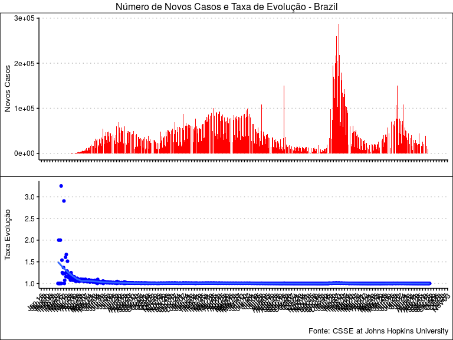

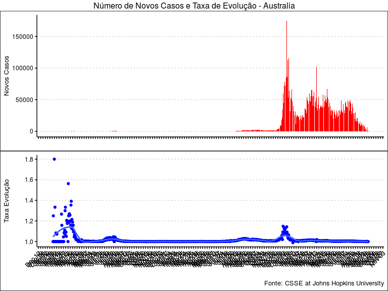

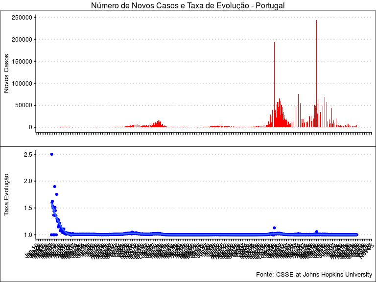

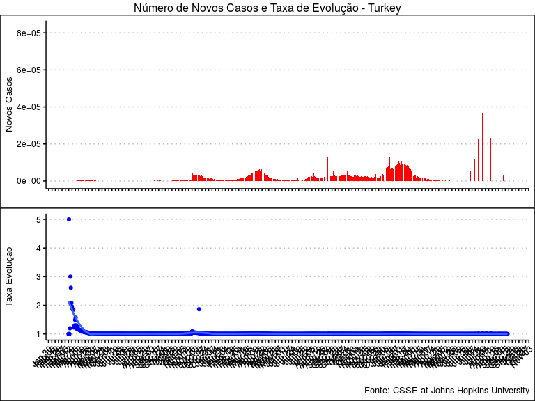

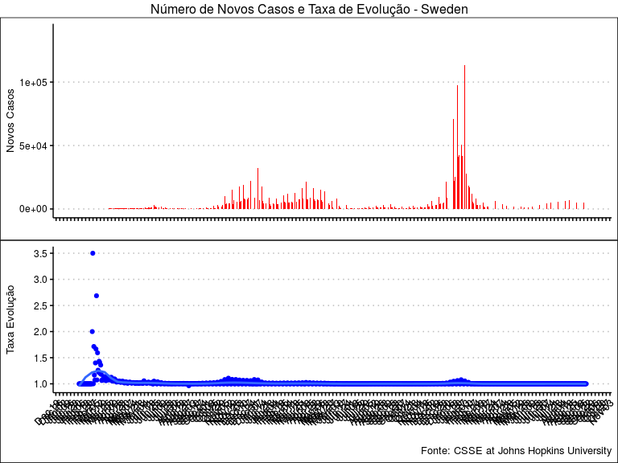

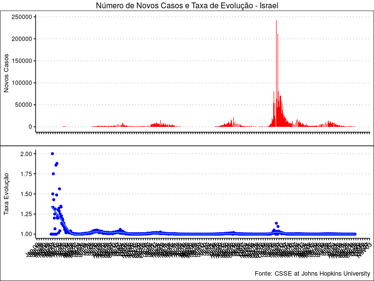

# Base de dados do Worldometer

Esta base de dados tem uma atualização bem interessante, com algumas variáveis também interessantes.

Ela está disponível em `https://www.worldometers.info/coronavirus/`

O problema é que não achei nenhum `csv` ou `xlsx` para baixar; então vou a solução é fazer um *web scraping* e pegar os dados. Utilizando o pacote `rvest` e seguindo a dica [deste post](https://www.r-bloggers.com/using-rvest-to-scrape-an-html-table/) foi razoavelmente fácil.

**Após diversas mudanças na página do Worldometer, estou desistindo de manter estes *web scraping***

Depois de pegar a tabela em html e colocar em um `data.frame`, algumas limpezas e transformações são necessárias: algumas colunas, como a `NewCases`, tem o símbolo `+`; os números vieram formatados como *strings* com separador de milhar (`,`), e algumas outras coisas. Então, algumas manipulações serão feitas para acertar isso.

O Worldometer não contabiliza os casos do *Diamond Princess* ou contabiliza juntamente com algum país, ou países (da nacionalidade de cada pessoa). Então, estou retirando também para refletir o valor mostrado no site do Worldometer.

O Worldometer também passou a apresentar totais de alguns continentes ou regiões; como não está padronizado, ou seja, não estão agrupando por continentes, que seria fácil remover na filtragem; ao invés disso, colocaram por exemplo, *North America* e *South America*, mas não tem *Americas*. Depois do dia 09 ou 10 de abril, o Worldometer passou a incluir uma linha *World* na tabela. Assim, estou removendo de acordo com o que eles mudam no site.

# Dados do Kaggle - Coronavirus - Brazil

### Total de Casos pelos dados do Kaggle Brazil: 23-05-2021

| Casos Confirmados | Total Mortes | Letalidade |
| --- | --- | --- |
| 16083258 | 449068 | 2.8% |

Incorporando a estimativa da população brasileira com os dados do IBGE, publicados em Janeiro de 2020, conforme esta página: [IBGE - Estimativas População, enviada ao TCU](https://www.ibge.gov.br/estatisticas/sociais/populacao/9103-estimativas-de-populacao.html?=&t=resultados)

[figure not shown]

| Estado | Casos | Mortes | Casos1M | Mortes1M | Letalidade |
| --- | --- | --- | --- | --- | --- |
| AC | 81413 | 1635 |  |  | 2% |
| AL | 188958 | 4607 |  |  | 2.4% |
| AM | 382487 | 12920 |  |  | 3.4% |
| AP | 110403 | 1657 |  |  | 1.5% |
| BA | 983587 | 20428 |  |  | 2.1% |
| CE | 770432 | 19815 |  |  | 2.6% |
| DF | 398450 | 8466 |  |  | 2.1% |
| ES | 470020 | 10512 |  |  | 2.2% |
| GO | 595328 | 16559 |  |  | 2.8% |
| MA | 284301 | 7896 |  |  | 2.8% |

[output cut: 17 more lines]

# Dados do Brasil a partir do Projeto Brasil.io

Descobri em 15/04/2020 este projeto fantástico: [Brasil.io](https://brasil.io/home)

> **O Brasil em dados libertos**

> Repositório de dados públicos disponibilizados em formato acessível

Dentre as diversas bases de dados que eles disponibilizam, tem uma sobre a COVID-19 em território brasileiro.

Esta é uma primeira utilização, simples, para entender a base. Como esta base contém informações dos municípios brasileiros, penso que será possível explorá-la bastante.

### Total de Casos pelos dados do Brasil.io: 27-03-2022

| Casos Confirmados | Total Mortes | Letalidade |
| --- | --- | --- |
| 29849740 | 659159 | 2.2% |

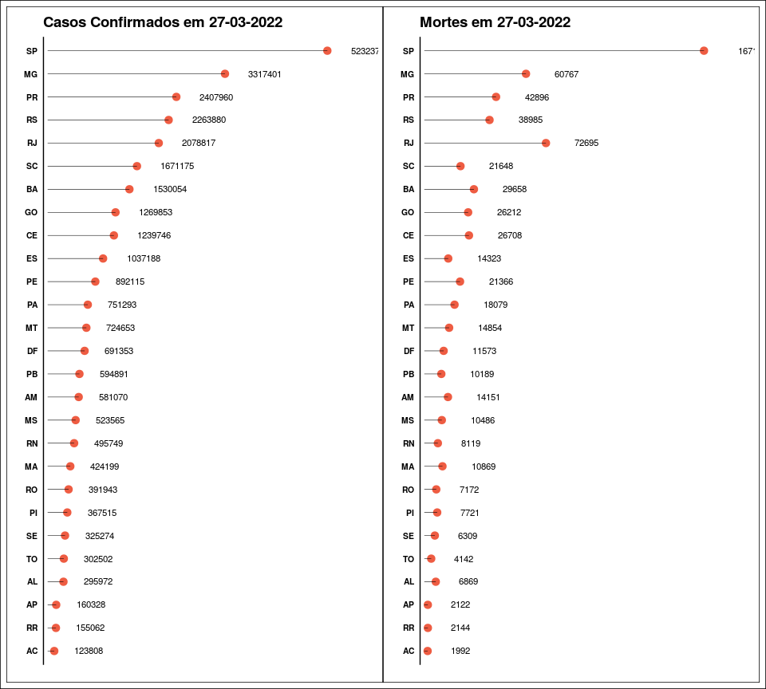

[**HOME**](https://momenezes.github.io/covid19/) Página gerada em: “Tue 20 Sep 2022 03:04:18 AM -03”